# Módulo 5: Visualización de datos con {ggplot2}

Curso R

Visualización

Bases de datos

Author

Gerardo Esteban, Gómez-Santiago

Published

August 14, 2026

## Introducción

El software R ya no se queda solamente en el análisis estrictamente estadístico, es tambien una herramienta con grandes capacidades comunicativas, la personalización de gráficos es una de las más demandadas.  
En este tutorial veremos como utilizar una librería `{ggplot2}`, cuya sintaxis es bastante intuitiva y ofrece mucha flexibilidad en el diseño del gráfico.  
Otras librerías que utilizaremos son:

- `giscoR`, la cual nos permite obtener las coordenadas geográficas de los países.
- `ggrepel`, una extensión de `ggplot2` que nos ayuda a trabajar con etiquetas en gráficos de dispersión.
- `extrafont`, que nos permite modificar la fuente de la letra.
- `patchwork`, que nos permite unir gráficos.
- `ggspatial`, un complemento de `ggplot2` para agregar detalles a los mapas.

## Datos a gráficar

La visualización que realizaremos es un mapa con el valor del índice de democracia calculado por [VDEM](https://www.v-dem.net/) y un gráfico de dispersión en el que vemos la relación entre el índice de democracia y el PIB per cápita medido por el [Banco Mundial](https://data.worldbank.org/) para el año 2019.  
Los datos estan contenidos en un archivo `.RData` llamado **ShapefileDemoc_Gdp.RData**, lo pueden encontrar en el [repositorio de GitHub](https://github.com/GomezGerardoEsteban/Tidyverso/tree/7ed8174f0c753a0ceed3c82fce135f7d55cd145f/TallerR).

### Obtención de datos

En el siguiente bloque de código limpiamos el ambiente de trabajo, activamos las librerías a utilizar y cargamos la base de datos.

```r
rm(list = ls())

# Librerias

library(tidyverse)
library(sf)
library(classInt)
library(ggspatial)
library(patchwork)
library(extrafont)
library(ggrepel)

# Cargo la base de datos

# Es un archivo .RData, estos se cargan con el comando 'load()' y no es necesario
# ponerle un nombre, se carga con el nombre que le puso quien exporto la base.

load(file = "bases/ShapefileDemoc_Gdp.RData")

dim(mapa)
```

```
[1] 257  10
```

```r
mapa <- mapa %>%
  filter(!is.na(v2x_polyarchy))
```

## Establecimiento de la paleta de colores para la variable `v2x_polyarchy`

La visualización de un mapa en el que las unidades territoriales toman distintas tonalidades según el valor de una variable continúa, es una de las visualizaciones mas utilizadas en mapas, R ofrece algunas tonalidades por defecto, lo que haremos en este caso es seleccionar los colores de una paleta especifica.

Lo primero que debo hacer es definir los quiebres o intervalos en la variable continua a partir de los cúales voy a establecer el color, esto lo hago con la función `classInt::classIntervals`.

```r
breaks <- classInt::classIntervals(var = mapa$v2x_polyarchy, # Defino la variable a partir de la cual crear los intervalos
                                   n = 8,                    # Establezco el número de intervalos
                                   style = "pretty")         # Criterio para el establecimiento de intervalos

breaks <- breaks$brks                                        # Almaceno los quiebres en un vector de nombre breaks

breaks
```

```
 [1] 0.0 0.1 0.2 0.3 0.4 0.5 0.6 0.7 0.8 0.9 1.0
```

Establecidos los quiebres, obtengo los colores, debo obtener un color por cada intervalo. Para ello, utilizo la función `hcl.colors`, la paleta que utilizaremos es `Zissou 1`.

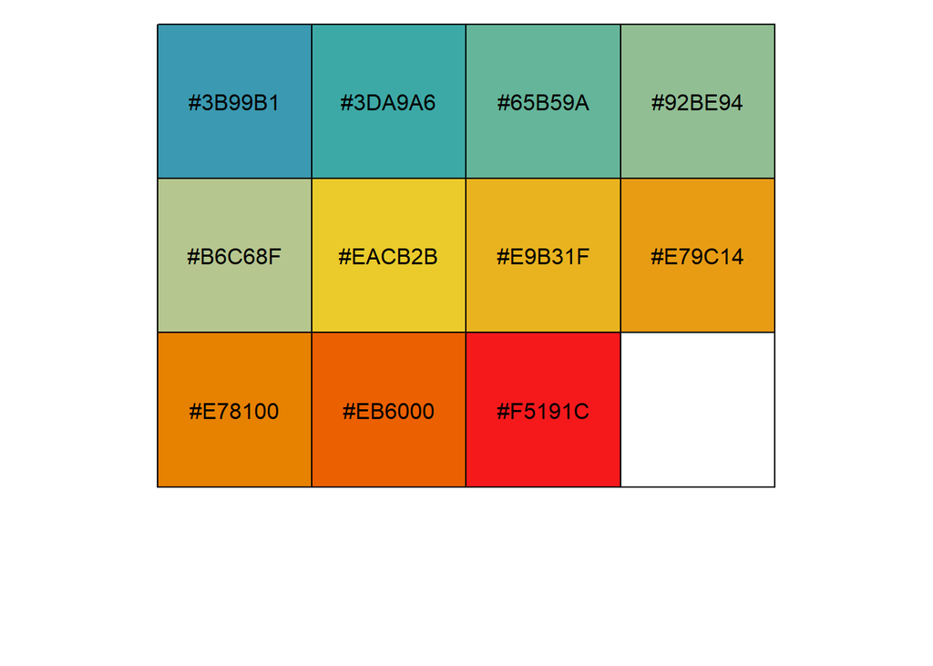

```r
colors <- hcl.colors(n = length(breaks),   # Longitud de breaks (número de colores a utilizar)
                     palette = "Zissou 1") # Paleta a utilizar, se pueden consultar más paletas ejecutando 'hcl.pals()'

scales::show_col(colors)  # Función para visualizar la paleta
```

La paleta que obtuvimos es de 11 colores, sin embargo, como la variable a gráficar es continua, los 11 pueden resultar una limitante al momento de reflejar la variación de la variable.  
Lo que debemos hacer es utilizar estos colores como base y expandir las tonalidades entre colores, esto lo podemos hacer con la función `colorRampPalette`.

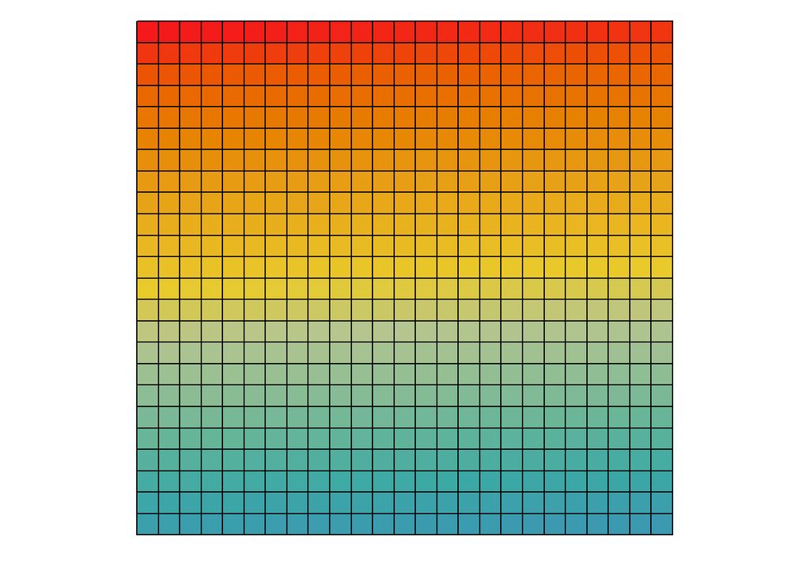

```r
textura <- colorRampPalette(colors = colors)(600) # Genero 600 tonalidades

textura <- rev(textura)                           # Por preferencias personales en la visualización, prefiero el azul para países mas democraticos y el rojo para menos democraticos. Por eso invierto el vector de colores con la funcion 'rev()'

scales::show_col(textura, labels = F)
```

## Realización del mapa

El paquete `ggplot2` trabaja de manera simple con datos geográficos, el `geom` necesario para ello es `geom_sf()`

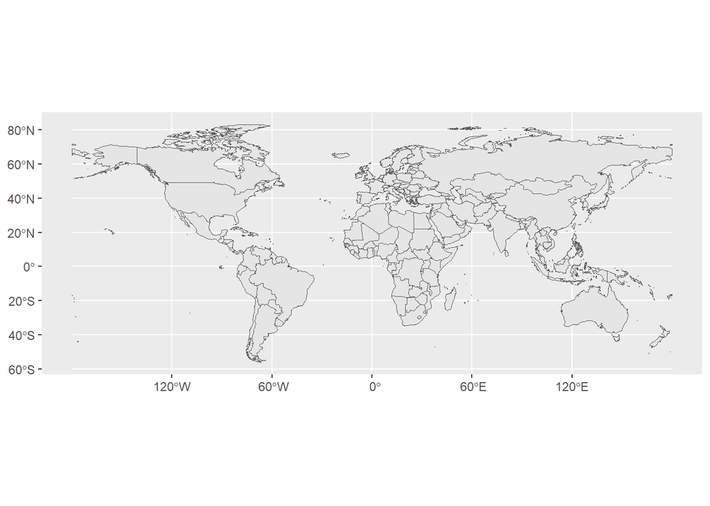

```r
mapa %>%
  ggplot() +
  geom_sf()
```

Lo que debemos agregar ahora es el relleno de los países a partir de la variable `v2x_polyarchy`

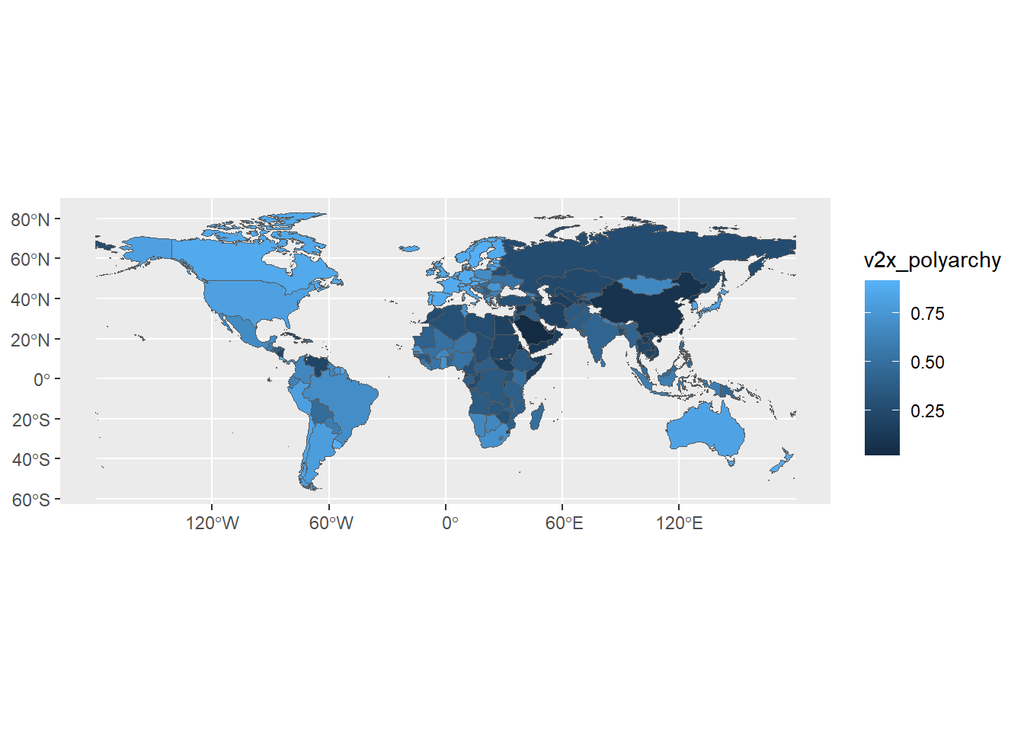

```r
mapa %>%
  ggplot() +
  geom_sf(mapping = aes(fill = v2x_polyarchy))
```

Pedimos que utilice la paleta ya creada

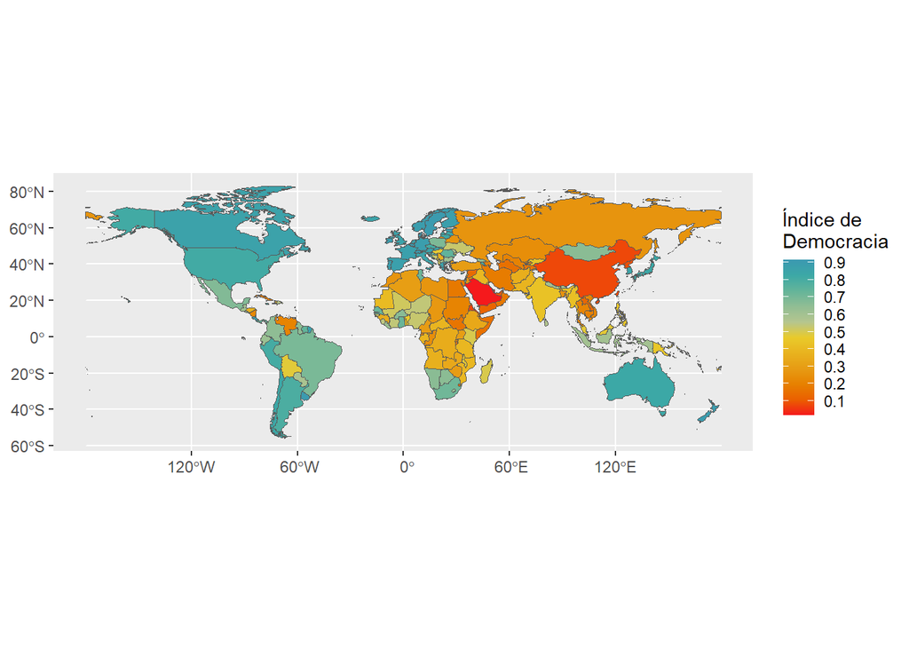

```r
mapa %>%
  ggplot() +
  geom_sf(mapping = aes(fill = v2x_polyarchy)) +
  scale_fill_gradientn(
    name = "Índice de\nDemocracia",
    breaks = breaks,
    labels = round(breaks, 1),
    colors = textura
  )
```

Añado titulo, subtitulo y quito nombres en los ejes

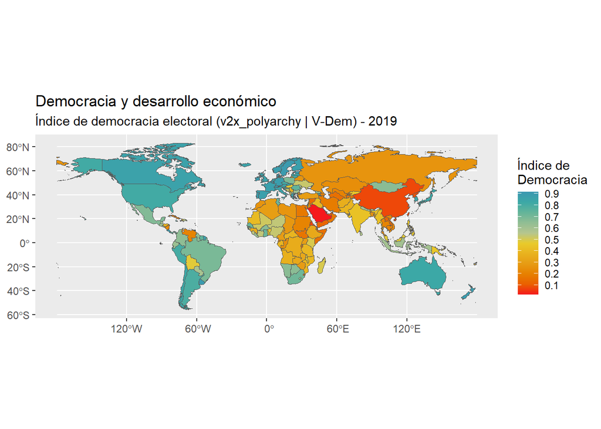

```r
mapa %>%
  ggplot() +
  geom_sf(mapping = aes(fill = v2x_polyarchy)) +
  scale_fill_gradientn(
    name = "Índice de\nDemocracia",
    breaks = breaks,
    labels = round(breaks, 1),
    colors = textura
  ) +
  labs(title = "Democracia y desarrollo económico",
       subtitle = "Índice de democracia electoral (v2x_polyarchy | V-Dem) - 2019",
       x = NULL,
       y = NULL,
       caption = NULL)
```

Inserto rosa de los vientos

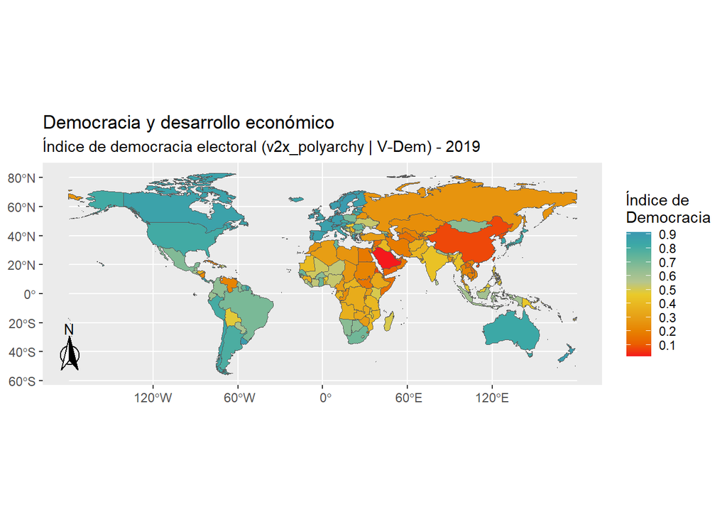

```r
mapa %>%
  ggplot() +
  geom_sf(mapping = aes(fill = v2x_polyarchy)) +
  scale_fill_gradientn(
    name = "Índice de\nDemocracia",
    breaks = breaks,
    labels = round(breaks, 1),
    colors = textura
  ) +
  labs(title = "Democracia y desarrollo económico",
       subtitle = "Índice de democracia electoral (v2x_polyarchy | V-Dem) - 2019",
       x = NULL,
       y = NULL,
       caption = NULL) +
  annotation_north_arrow(location = "bl",
                         width = unit(0.8, "cm"),
                         height = unit(1.2, "cm"),
                         style = north_arrow_fancy_orienteering)
```

Dentro de la función `theme` manipulo el diseño del gráfico

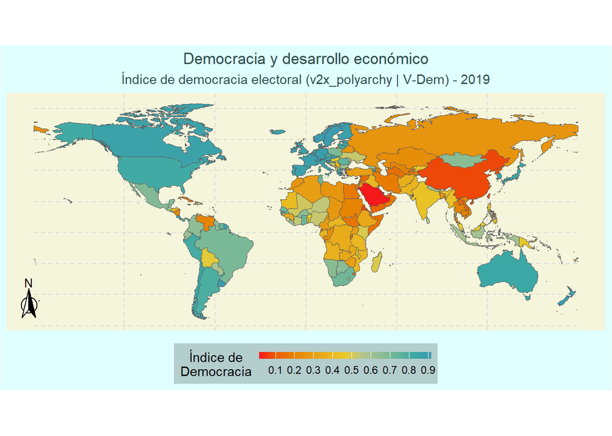

```r
mapa %>%
  ggplot() +
  geom_sf(mapping = aes(fill = v2x_polyarchy)) +
  scale_fill_gradientn(
    name = "Índice de\nDemocracia",
    breaks = breaks,
    labels = round(breaks, 1),
    colors = textura
  ) +
  labs(title = "Democracia y desarrollo económico",
       subtitle = "Índice de democracia electoral (v2x_polyarchy | V-Dem) - 2019",
       x = NULL,
       y = NULL,
       caption = NULL) +
  annotation_north_arrow(location = "bl",
                         width = unit(0.8, "cm"),
                         height = unit(1.2, "cm"),
                         style = north_arrow_fancy_orienteering) +
  theme(text = element_text(family = "Cambria"),
        plot.title = element_text(hjust = 0.5, color = "darkslategray"),
        plot.subtitle = element_text(hjust = 0.5, color = "darkslategray"),
        plot.background = element_rect(fill = "lightcyan"),
        panel.background = element_rect(fill = "beige"),
        panel.grid = element_line(color = "grey85", linetype = "dashed"),
        legend.position = "bottom",
        axis.text = element_blank(),
        axis.ticks = element_blank(),
        legend.key.height = unit(0.2, "cm"),
        legend.key.width = unit(1, "cm"),
        legend.title = element_text(hjus = 0.5),
        legend.background = element_rect(fill = "lightcyan3"))
```

Para exportar la visualización, guardo el gráfico en un objeto y utilizo el comando `ggsave()`, exportar la visualización utilizando esta función, garantiza que el gráfico no pierda definición. Al ejecutarlo el gráfico se guarda en mi directorio de trabajo.

```r
# Guardo la visualización

graficoMapa <- mapa %>%
  ggplot() +
  geom_sf(mapping = aes(fill = v2x_polyarchy)) +
  scale_fill_gradientn(
    name = "Índice de\nDemocracia",
    breaks = breaks,
    labels = round(breaks, 1),
    colors = textura
  ) +
  labs(title = "Democracia y desarrollo económico",
       subtitle = "Índice de democracia electoral (v2x_polyarchy | V-Dem) - 2019",
       x = NULL,
       y = NULL,
       caption = NULL) +
  annotation_north_arrow(location = "bl",
                         width = unit(0.8, "cm"),
                         height = unit(1.2, "cm"),
                         style = north_arrow_fancy_orienteering) +
  theme(text = element_text(family = "Cambria"),
        plot.title = element_text(hjust = 0.5, color = "darkslategray"),
        plot.subtitle = element_text(hjust = 0.5, color = "darkslategray"),
        plot.background = element_rect(fill = "lightcyan"),
        panel.background = element_rect(fill = "beige"),
        panel.grid = element_line(color = "grey85", linetype = "dashed"),
        legend.position = "bottom",
        axis.text = element_blank(),
        axis.ticks = element_blank(),
        legend.key.height = unit(0.2, "cm"),
        legend.key.width = unit(1, "cm"),
        legend.title = element_text(hjus = 0.5),
        legend.background = element_rect(fill = "lightcyan3"))

# Exporto la visualizacion

ggsave(filename = "mapa_soloDemoc.png", # Nombre de la imagen en mi directorio de trabajo, es importante la extensión '.png'
       plot = graficoMapa,              # Objeto a exportar
       dpi = 500,                       # Definición de pixeles
       width = 8,                       # Ancho
       height = 4)                      # Alto
```

## Gráfico de dispersión v2x_polyarchy ~ NY.GDP.PCAP.KD

La estructura para realizar gráficos con `ggplot2` es igual siempre, parto de una base, conecto con la función `ggplot()` y voy añadiendo capas que contienen epecificaciones de diseño.  
El `geom` para los diagramas de dispersión es `geom_point()`, debido a que la distribución del PIB per cápita presenta sesgo a la derecha, utilizaremos su transformación logarítmica, lo que permite que la variable tienda a una distribución normal.

Esta es la estructura inicial del gráfico

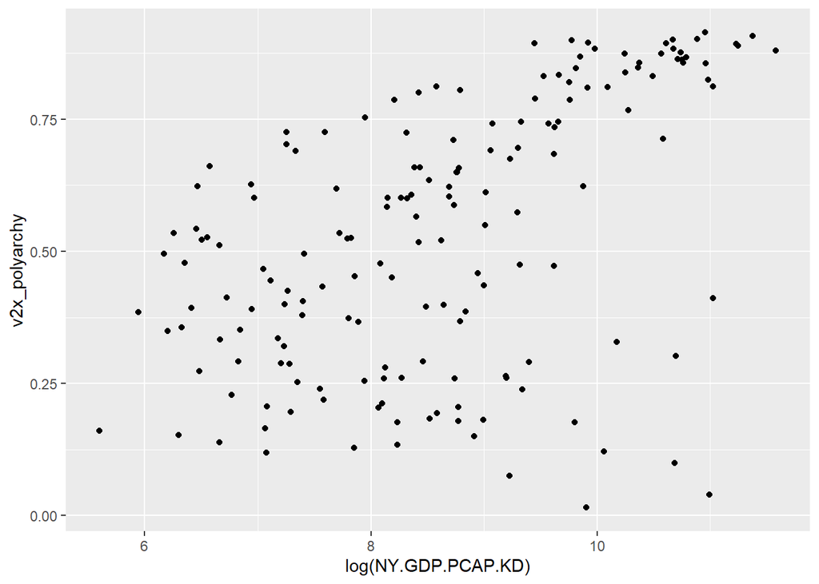

```r
mapa %>%
  ggplot(mapping = aes(x = log(NY.GDP.PCAP.KD), y = v2x_polyarchy)) +
  geom_point()
```

Vamos a modificar la forma y el color de los puntos a partir del valor de ciertas variables, cuando quiero incorporar alguna característica en el gráfico a partir del valor de cierta variable, es necesario especificar esto dentro del `aes()`, el cual puede estar definido en el `ggplot()` inicial o dentro de los `geom`.  
En este caso modificaremos el color y la forma de los puntos a partir variables contenidas en nuestra base de datos.

- `size`: tamaño de los puntos (en función de la población total)
- `shape`: forma de los puntos (en función de los contienes)
- `color`: color de los puntos (en función del índice de democracia)

Otras especificaciones son `alpha` para agregar transparencia a los puntos y `show.legend = F` para que no aparezcan leyendas al costado del gráfico.

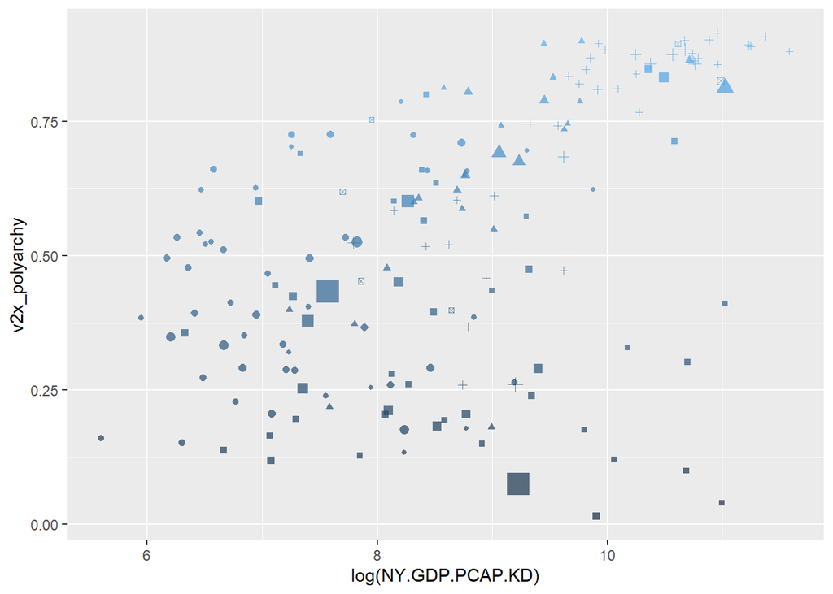

```r
mapa %>%
  ggplot(mapping = aes(x = log(NY.GDP.PCAP.KD), y = v2x_polyarchy)) +
  geom_point(mapping = aes(shape = continentes,
                           color = v2x_polyarchy,
                           size = SP.POP.TOTL),
             alpha = 0.7,
             show.legend = F)
```

Las especificaciones de tipos de forma, tamaño y color son las que pone por defecto el R en función de las variables especificadas, para modificar esas especificaciones, debo utilizar las funciones `scale`. Utilizaremos la misma paleta de colores del mapa.

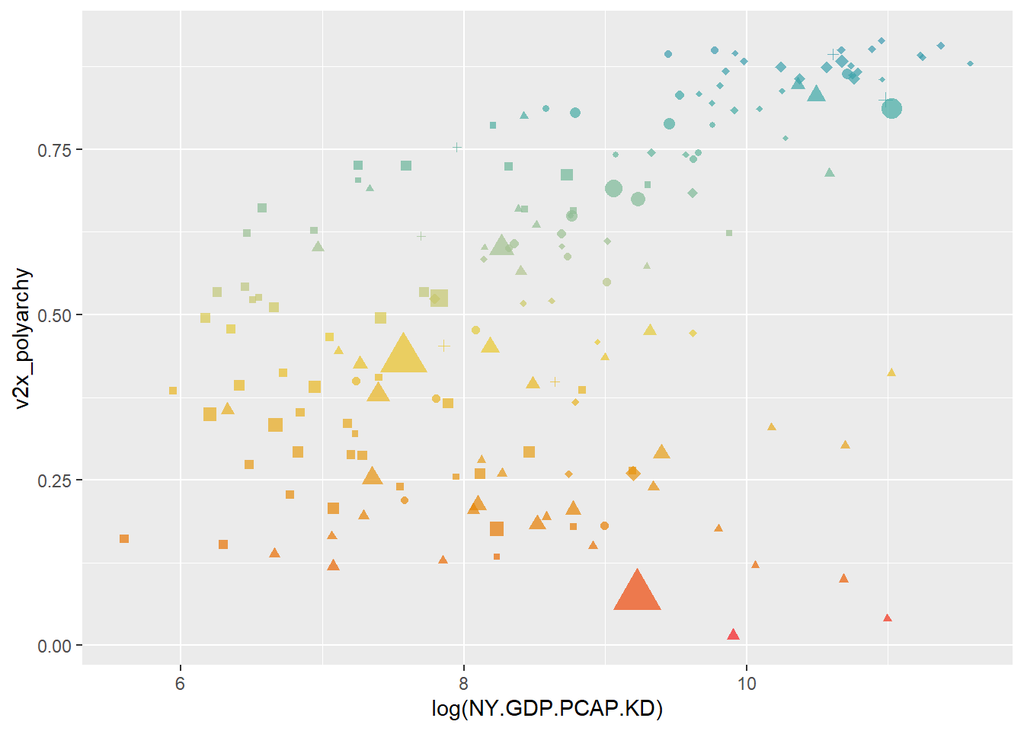

```r
mapa %>%
  ggplot(mapping = aes(x = log(NY.GDP.PCAP.KD), y = v2x_polyarchy)) +
  geom_point(mapping = aes(shape = continentes,
                           color = v2x_polyarchy,
                           size = SP.POP.TOTL),
             alpha = 0.7,
             show.legend = F) +
  scale_color_gradientn(
    name = "Índice de\nDemocracia",
    breaks = breaks,
    labels = round(breaks, 1),
    colors = textura
  ) +
  scale_shape_manual(values = c(15,16,17,18,3)) +
  scale_size_continuous(range = c(1,8))
```

Añadimos nuevos `geom` al gráfico, `geom_smooth()` nos permite visualizar la recta de regresión entre las variables y `geom_text_repel()` nos permite colocar el codigo a tres carácteres de cada país, evitando el solapamiento de los mismos.

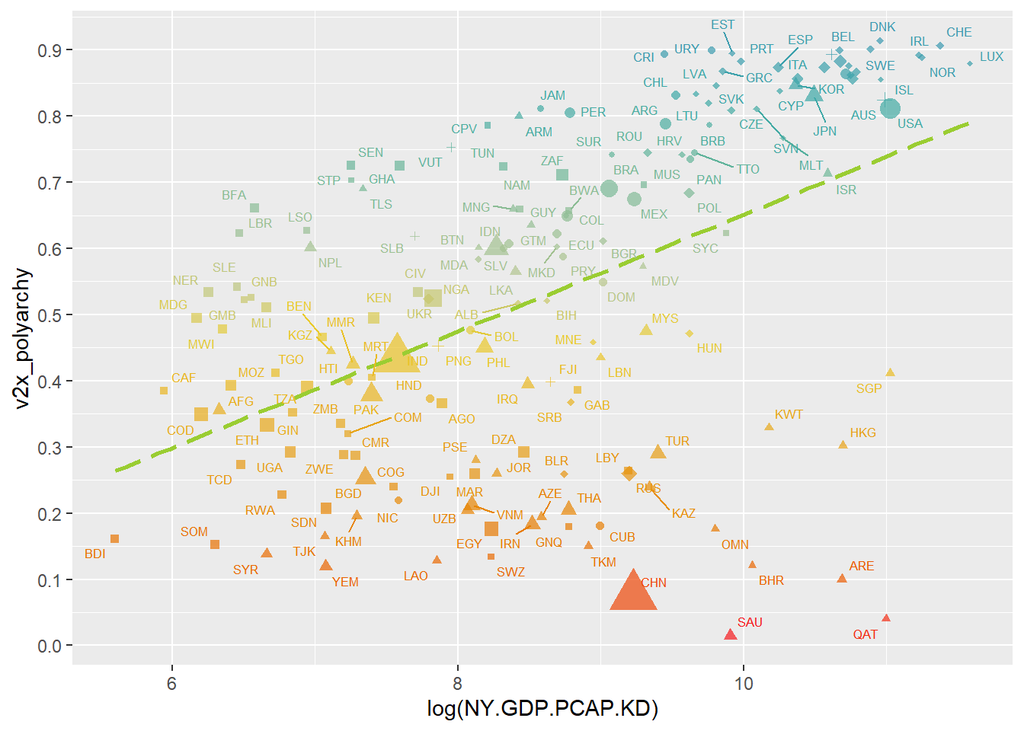

```r
mapa %>%
  ggplot(mapping = aes(x = log(NY.GDP.PCAP.KD), y = v2x_polyarchy)) +
  geom_point(mapping = aes(shape = continentes,
                           color = v2x_polyarchy,
                           size = SP.POP.TOTL),
             alpha = 0.7,
             show.legend = F) +
  scale_color_gradientn(
    name = "Índice de\nDemocracia",
    breaks = breaks,
    labels = round(breaks, 1),
    colors = textura
  ) +
  scale_shape_manual(values = c(15,16,17,18,3)) +
  scale_size_continuous(range = c(1,8)) +
  scale_y_continuous(breaks = breaks) +
  geom_smooth(method = "lm", se = F,
              color = "olivedrab3",
              linetype = "longdash") +
  geom_text_repel(mapping = aes(label = ISO3_CODE,
                          color = v2x_polyarchy),
            size = 2.3,
            show.legend = F)
```

Añadimos titulos a los ejes y una nota al pie con algunas aclaraciones

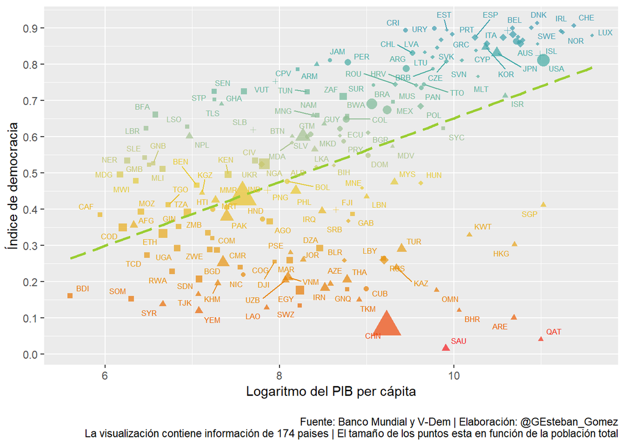

```r
mapa %>%
  ggplot(mapping = aes(x = log(NY.GDP.PCAP.KD), y = v2x_polyarchy)) +
  geom_point(mapping = aes(shape = continentes,
                           color = v2x_polyarchy,
                           size = SP.POP.TOTL),
             alpha = 0.7,
             show.legend = F) +
  scale_color_gradientn(
    name = "Índice de\nDemocracia",
    breaks = breaks,
    labels = round(breaks, 1),
    colors = textura
  ) +
  scale_shape_manual(values = c(15,16,17,18,3)) +
  scale_size_continuous(range = c(1,8)) +
  geom_smooth(method = "lm", se = F,
              color = "olivedrab3",
              linetype = "longdash") +
  scale_y_continuous(breaks = breaks) +
  geom_text_repel(mapping = aes(label = ISO3_CODE,
                          color = v2x_polyarchy),
            size = 2.3,
            show.legend = F) +
  labs(x = "Logaritmo del PIB per cápita",
       y = "Índice de democracia",
       caption = "\nFuente: Banco Mundial y V-Dem | Elaboración: @GEsteban_Gomez\nLa visualización contiene información de 174 paises | El tamaño de los puntos esta en función de la población total")
```

Una de las limitaciones que tiene en este momento nuestro gráfico, es que no hay ninguna leyenda que indique a que continente corresponde la forma de los puntos. Para incluirlos, crearemos una base de datos con esta información, una de las ventajas de `ggplot2` es que permite trabajar con más de una base de datos en la misma visualización.

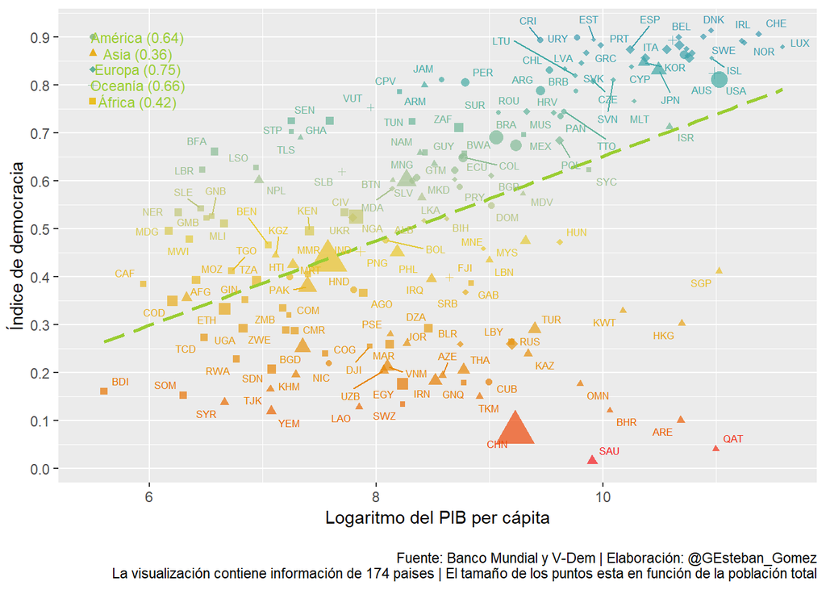

```r
# Base con la información de los continentes para incluir como leyenda dentro del gráfico

continentes <- mapa %>%
  st_drop_geometry() %>%
  group_by(continentes) %>%
  summarise(mean = mean(v2x_polyarchy, na.rm = T)) %>%
  mutate(x = 5.5,
         y = c(0.9, 0.866, 0.833, 0.8, 0.766),
         label = str_c(continentes, " (", round(mean, 2), ")"))

# grafico

mapa %>%
  ggplot(mapping = aes(x = log(NY.GDP.PCAP.KD), y = v2x_polyarchy)) +
  geom_point(mapping = aes(shape = continentes,
                           color = v2x_polyarchy,
                           size = SP.POP.TOTL),
             alpha = 0.7,
             show.legend = F) +
  scale_color_gradientn(
    name = "Índice de\nDemocracia",
    breaks = breaks,
    labels = round(breaks, 1),
    colors = textura
  ) +
  scale_shape_manual(values = c(15,16,17,18,3)) +
  scale_size_continuous(range = c(1,8)) +
  geom_smooth(method = "lm", se = F,
              color = "olivedrab3",
              linetype = "longdash") +
  scale_y_continuous(breaks = breaks) +
  geom_text_repel(mapping = aes(label = ISO3_CODE,
                          color = v2x_polyarchy),
            size = 2.3,
            show.legend = F) +
  geom_point(data = continentes,              # Incluyo los puntos para simbolizar los continentes
             mapping = aes(x = x,
                           y = y,
                           shape = continentes,
                           color = mean),
             show.legend = F) +
  annotate(geom = "text",                     # Incluyo el nombre de los continentes con una leyenda del promedio del índice de democracia
           x = continentes$x + 0.4,
           y = continentes$y,
           label = continentes$label,
           size = 3.,
           color = "olivedrab3",
           family = "Cambria") +
  labs(x = "Logaritmo del PIB per cápita",
       y = "Índice de democracia",
       caption = "\nFuente: Banco Mundial y V-Dem | Elaboración: @GEsteban_Gomez\nLa visualización contiene información de 174 paises | El tamaño de los puntos esta en función de la población total")
```

Finalmente, modifíco el diseño del gráfico con especificaciones dentro del comando `theme()`

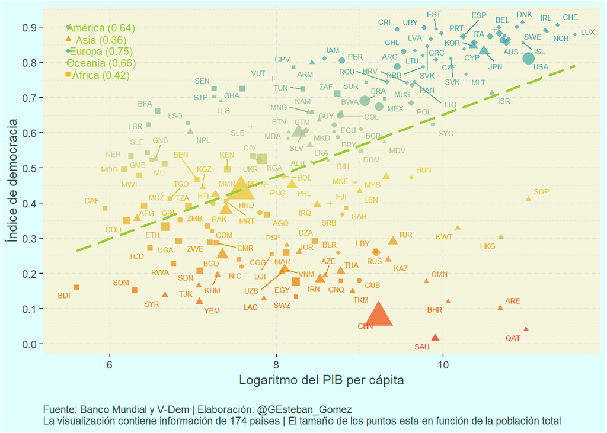

```r
dispersion <- mapa %>%
  ggplot(mapping = aes(x = log(NY.GDP.PCAP.KD), y = v2x_polyarchy)) +
  geom_point(mapping = aes(shape = continentes,
                           color = v2x_polyarchy,
                           size = SP.POP.TOTL),
             alpha = 0.7,
             show.legend = F) +
  scale_color_gradientn(
    name = "Índice de\nDemocracia",
    breaks = breaks,
    labels = round(breaks, 1),
    colors = textura
  ) +
  scale_shape_manual(values = c(15,16,17,18,3)) +
  scale_size_continuous(range = c(1,8)) +
  geom_smooth(method = "lm", se = F,
              color = "olivedrab3",
              linetype = "longdash") +
  scale_y_continuous(breaks = breaks) +
  geom_text_repel(mapping = aes(label = ISO3_CODE,
                          color = v2x_polyarchy),
            size = 2.3,
            show.legend = F) +
  geom_point(data = continentes,              # Incluyo los puntos para simbolizar los continentes
             mapping = aes(x = x,
                           y = y,
                           shape = continentes,
                           color = mean),
             show.legend = F) +
  annotate(geom = "text",                     # Incluyo el nombre de los continentes con una leyenda del promedio del índice de democracia
           x = continentes$x + 0.4,
           y = continentes$y,
           label = continentes$label,
           size = 3.,
           color = "olivedrab3",
           family = "Cambria") +
  labs(x = "Logaritmo del PIB per cápita",
       y = "Índice de democracia",
       caption = "\nFuente: Banco Mundial y V-Dem | Elaboración: @GEsteban_Gomez\nLa visualización contiene información de 174 paises | El tamaño de los puntos esta en función de la población total") +
  theme(text = element_text(family = "Cambria"),
        plot.caption = element_text(hjust = 0, color = "darkslategray"),
        plot.background = element_rect(fill = "lightcyan"),
        panel.background = element_rect(fill = "beige"),
        panel.grid = element_line(color = "gray90", linetype = "dashed"),
        axis.title = element_text(color = "darkslategray"))

dispersion
```

## Unión de los gráficos

Ya generamos las visualizaciones por separado, ahora, utilizando la librería `patchwork` es posible juntar ambas visualizaciones en una sola.

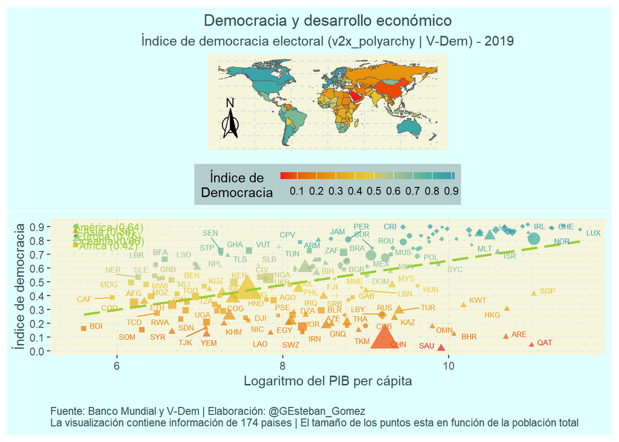

```r
graficoFinal <- wrap_plots(graficoMapa,       # Primer grafico
                           dispersion,        # segundo grafico
                           nrow = 2,          # Numero de filas (al ser dos graficos y especificar 2 filas, vamos a tener un grafico encima del otro)
                           heights = c(0.7,   # Altura del primer grafico
                                       1)     # Altura del segundo grafico
                           )

graficoFinal
```

La previsualización de los gráficos unidos es limitada, para verificar que el gráfico quedo como esperabas y que tiene las dimensiones correctas lo mejor es exportarlo, es importante ajustar los comandos `height` y `width` dentro de la función `ggsave()` hasta obtener las dimensiones deseadas.

```r
ggsave(filename = "mapaDispersion_soloDemoc.png",
       plot = graficoFinal,
       dpi = 500,
       width = 10,
       height = 12)
```